# Exploring the BRFSS 2013 Data (Exploratory Data Analysis)

Sierra Dahal

10/21/2021

## Setup

### Load packages

Load necessary packages and dataset

```r
library("ggplot2")
library("dplyr")
```

## Part 1: Data

Observations for the BRFSS data analysis are collected in a cross-selectional uniform manner via telephone survey by landline or cellphone conducted by the state health department monthly. The number of interviews within each state differs based on funding and size of region. To be a selected region there had to be 500 adult respondents or more in the 2011 BRFSS combined for cellphone and landline data. Contrary to conducting a cellphone user participant, the landline telephone survey selects a random adult living within the household to participate. Prior to 2011, the statistical method that was used was known as post stratification to weight BRFSS survey data. Currently a new methodology called iterative stratification is used which allows more demographic variables to be considered to reduce bias and increase the overall representation of the population. However, this study is observational in nature and only correlation can be evaluated hence, causality cannot be implied. And since this study collected data via telephone surveys non-response bias must be considered.

Below is an overview of the demographics in this data set

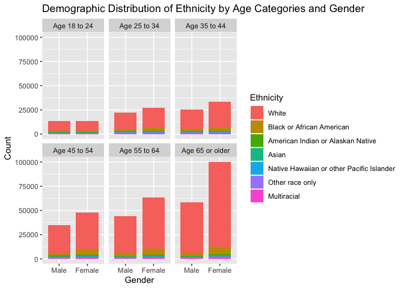

```r
#The distribution of age and sex among ethnicity in this data set
demographics <- brfss2013 %>%
  select(X_age_g, X_mrace1, sex)
demographics <-  na.omit(demographics)
ggplot(demographics, aes(fill=X_mrace1, x=sex)) + geom_bar(width = 0.8) + ggtitle("Demographic Distribution of Ethnicity by Age Categories and Gender") + xlab("Gender") + ylab("Count") + labs(fill = "Ethnicity") + facet_wrap(~X_age_g)
```

## Part 2: Research questions

Question #1: Does income have an influence on the number of reported mental health days in a month for men and women?

Question #2: Does the marital status of men influence the diagnosis of diabetes?

Question #3: Is there a relationship between the type of chronic disease and the getting the annual flu shot?

## Part 3: Exploratory data analysis

### Question #1

I will be exploring the relationship between the number of mental health days reported among men and women and their level of income.

First I created a new data frame called “MH_income” and selected the variables of interest form the original data set (brfss2013). The variables of interest are the number of mental health days reported as not good within 30 days (menthlth), the levels of different incomes (income2), and gender (sex).

```r
#Created a new data set
MH_income <- brfss2013 %>%
  select(income2, menthlth, sex)
#Omitted NA values
MH_income <-  na.omit(MH_income)
```

Next, I created a numerical summary of the number of mental health days reported among males and females based on their level of income reported.

#### Male Summary

```r
#Male Summary
M <- MH_income %>%
group_by(income2) %>%
filter(sex == "Male") %>%
summarise(mhmean = mean(menthlth), mhmedian = median(menthlth), mhsd = sd(menthlth), iqr_menthlth = IQR(menthlth), mhmin = min(menthlth), mhmax = max(menthlth), n=n())
M
```

```
## # A tibble: 8 × 8
##   income2           mhmean mhmedian  mhsd iqr_menthlth mhmin mhmax     n
##   <fct>              <dbl>    <dbl> <dbl>        <dbl> <int> <int> <int>
## 1 Less than $10,000   7.17        0 11.0            10     0    30  8020
## 2 Less than $15,000   6.02        0 10.2             7     0    30  8939
## 3 Less than $20,000   4.60        0  9.03            4     0    30 12254
## 4 Less than $25,000   3.79        0  8.28            2     0    30 15422
## 5 Less than $35,000   2.84        0  7.17            1     0    30 19328
## 6 Less than $50,000   2.41        0  6.58            0     0    30 26515
## 7 Less than $75,000   2.01        0  5.82            0     0    30 29180
## 8 $75,000 or more     1.50        0  4.91            0     0    30 56170
```

The male summary table above shows interesting results. The mean mental health days per month are the highest among males who reported their income as <$10,000. The lowest mean calculated is among males with an income >$75,000. The median among all groups is calculated as 0 and the maximum value for all groups was 30 days. By seeing the median calculated as 0 among all groups, we know that up to 50% of men in each income level have zero mental health days per month.

#### Female Summary

```r
#Female Summary
F <- MH_income %>%
group_by(income2) %>%
filter(sex == "Female") %>%
summarise(mhmean = mean(menthlth), mhmedian = median(menthlth), mhsd = sd(menthlth), mhmin = min(menthlth), iqr_menthlth = IQR(menthlth), mhmax = max(menthlth), n=n())
F
```

```
## # A tibble: 8 × 8
##   income2           mhmean mhmedian  mhsd mhmin iqr_menthlth mhmax     n
##   <fct>              <dbl>    <dbl> <dbl> <int>        <dbl> <int> <int>
## 1 Less than $10,000   8.13        1 11.4      0           15    30 16588
## 2 Less than $15,000   6.50        0 10.4      0           10    30 17125
## 3 Less than $20,000   5.09        0  9.27     0            5    30 21865
## 4 Less than $25,000   4.50        0  8.77     0            4    30 25523
## 5 Less than $35,000   3.70        0  7.90     0            3    30 28788
## 6 Less than $50,000   3.21        0  7.22     0            2    30 34297
## 7 Less than $75,000   2.87        0  6.69     0            2    30 35521
## 8 $75,000 or more     2.34        0  5.84     0            2    30 58927
```

The female summary table above also shows interesting results. The mean mental health days per month are the highest among females who reported their income as <$10,000. The lowest mean calculated is among females with an income >$75,000. The median among all groups is reported as 0 except for the income category of <$10,000 which was reported to be 1. Just like the male summary, the female summary reported their maximum value for each level of income as 30. Looking at the calculated median value as 0 among all groups except income <$10,000, we know that up to 50% of women in each income level had zero mental health days per month except those who reported their income as <$10,000.

I created a box plot showing the numerical summaries that were calculated above. I chose a box plot since there are many outliers in the data and the mean and SD would be most affected by those outliers. Box plots are useful graphically because by examining the length of the box which represents the range among the middle 50% of the data (IQR = Q3-Q1) we can see where a majority of the data values lie. Also by examining where the top part of the box lies we can see where 75% of the data lies.

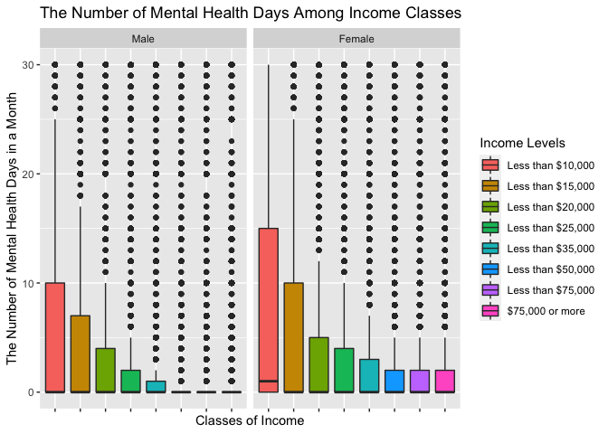

```r
ggplot(MH_income, aes(x=income2, y=menthlth, fill = income2))+ geom_boxplot() + scale_y_continuous(limits=c(0, 30), name = "The Number of Mental Health Days in a Month") + scale_x_discrete(name="Classes of Income") + ggtitle("The Number of Mental Health Days Among Income Classes") + facet_grid(. ~ sex) + labs(fill = "Income Levels") + theme(axis.text.x=element_blank())
```

The above side-by-side box plots graphically summarizes the 5 statistics (min, Q1, median, Q3, max) of the reported mental health days per month among income classes for males and females. Overall, there is visual pattern between the number of mental health days reported and levels of income. As the level of income increases the number of mental health days per month reported decreases. Perhaps those with more income have less monetary stress than those of lower income classes. When comparing the side-by-side box plot graphs for males and females we can see the female side-by-side box plot tends to be higher than their male counterparts. These results are not surprising as females tend to be more susceptible to having mental health days than males. However, we cannot conclude any results without appropriate statistical testing.

### Question #2

I will be exploring the diagnosis of diabetes among the relationship status reported by men.

First I created a new data set called “dm_marital” which will contain my variables of interest; gender, marital status, and diabetes diagnosis.

```r
#Created new data set
dm_marital <- brfss2013 %>%
select(sex, marital, diabete3)
#Omitted NA vales
dm_marital <-  na.omit(dm_marital)
```

Next I created a dataset only including males.

```r
#Created data set of only males
men <- filter(dm_marital, sex == 'Male')
```

Creating a table to show the proportions of each possible outcome

```r
#Table of proportions of men belonging to each group
prop_men <- men %>%
group_by(marital, diabete3) %>%
summarise(n=n()) %>%
mutate(prop=n/sum(n))
prop_men
```

```
## # A tibble: 18 × 4
## # Groups:   marital [6]
##    marital                         diabete3                             n   prop
##    <fct>                           <fct>                            <int>  <dbl>
##  1 Married                         Yes                              15456 0.136
##  2 Married                         No                               96536 0.848
##  3 Married                         No, pre-diabetes or borderline …  1895 0.0166
##  4 Divorced                        Yes                               4204 0.161
##  5 Divorced                        No                               21429 0.818
##  6 Divorced                        No, pre-diabetes or borderline …   550 0.0210
##  7 Widowed                         Yes                               2902 0.228
##  8 Widowed                         No                                9443 0.742
##  9 Widowed                         No, pre-diabetes or borderline …   379 0.0298
## 10 Separated                       Yes                                614 0.160
## 11 Separated                       No                                3151 0.821
## 12 Separated                       No, pre-diabetes or borderline …    75 0.0195
## 13 Never married                   Yes                               2719 0.0732
## 14 Never married                   No                               33967 0.915
## 15 Never married                   No, pre-diabetes or borderline …   452 0.0122
## 16 A member of an unmarried couple Yes                                385 0.0658
## 17 A member of an unmarried couple No                                5396 0.922
## 18 A member of an unmarried couple No, pre-diabetes or borderline …    73 0.0125
```

The table displays the number and proportions of men belonging to each possible category. Next, I will graph the results using a stacked bar plot to emphasize the proportions.

I changed the names of the values in the marital column so it would be better suited for the graph display.

```r
#Changed the names of the levels within the factor for graphical purposes
levels(men$marital) <- c("Married", "Divorced", "Windowed", "Seperated", "Single", "Couple")
```

Graphically displaying the conditional distribution of diabetes among the martial status of men. I considered those with pre-diabetes as not being diagnosed with diabetes.

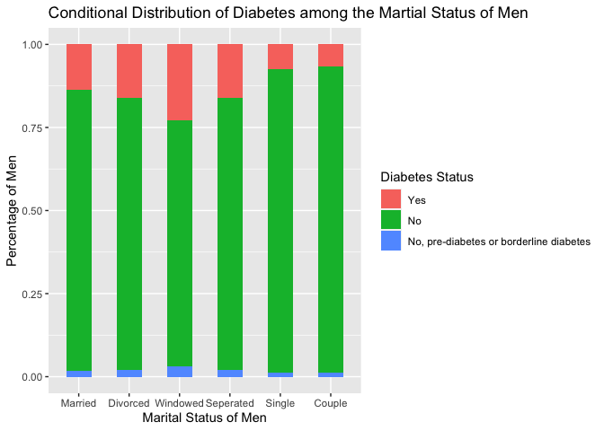

```r
ggplot(men, aes(fill=diabete3, x=marital)) + geom_bar(position = "fill", width = 0.5) + ggtitle("Conditional Distribution of Diabetes among the Martial Status of Men") + xlab("Marital Status of Men") + ylab("Percentage of Men") + labs(fill = "Diabetes Status")
```

According to the stacked bar graph, the proportion of diabetes was the highest among widowed men, followed by divorced, separated, married, then single and unmarried. Perhaps age may be an influence for the widowed category since both diabetes and becoming a widow tends to occur in advanced age. It is interesting to point out that men who are not married (single and couple category) are relatively similar in proportions of being diagnosed with diabetes. Again, age may be an influencing factor since most men in these two categories would tend to be younger in age. It is also interesting to point out that men who are divorced or separated reported similar proportions of diabetes diagnosis. We can also see that divorced and separated proportions were slightly higher than those who where married. Without statistical testing we cannot conclude the significance of the findings but perhaps men who are in a relationship or married tend to have less of a diabetes diagnosis than those who are divorced, separated, or became a widow.

### Question #3

I will be exploring the relationship between the types of chronic disease and the proportions of getting the annual flu shot.

I created a new data set called chronic_diseases that contained variables of interest all the chronic disease states reported in brfss2013 and whether if they got a flu shot (flushot6). Then I removed all NA values.

```r
#Created a new data set
chronic_diseases <- brfss2013 %>%
select(cvdinfr4, cvdcrhd4, cvdstrk3, asthma3, asthnow, chccopd1, chcscncr, chcocncr, havarth3, addepev2, diabete3, chckidny, flushot6)
#Omitted NA vales
chronic_diseases <-  na.omit(chronic_diseases)
```

Next, I created categories of disease states (Heart disease, Lung disease, Cancers, Arthritis, Mental Health, Endocrine, Kidney disease) and then summarized the total number of people belonging to each disease state and their proportion of getting a flu shot.

```r
#Proportions of flu shots from those diagnosed with heart disease
heart_disease <- chronic_diseases %>%
filter(cvdinfr4 == "Yes" | cvdcrhd4 == "Yes" | cvdstrk3 == "Yes") %>%
group_by(flushot6) %>%
summarise(n=n())%>%
mutate(prop=n/sum(n))
heart_disease
```

```
## # A tibble: 2 × 3
##   flushot6     n  prop
##   <fct>    <int> <dbl>
## 1 Yes       5372 0.589
## 2 No        3755 0.411
```

```r
#Proportions of flu shots from those diagnosed with lung disease
lung_disease <- chronic_diseases %>%
filter(asthma3 == "Yes" | asthnow == "Yes" | chccopd1 == "Yes") %>%
group_by(flushot6) %>%
summarise(n=n()) %>%
mutate(prop=n/sum(n))
lung_disease
```

```
## # A tibble: 2 × 3
##   flushot6     n  prop
##   <fct>    <int> <dbl>
## 1 Yes      28778 0.501
## 2 No       28717 0.499
```

```r
#Proportions of flu shots from those diagnosed with cancer
cancers <- chronic_diseases %>%
filter(chcscncr == "Yes" | chcocncr == "Yes") %>%
group_by(flushot6) %>%
summarise(n=n()) %>%
mutate(prop=n/sum(n))
cancers
```

```
## # A tibble: 2 × 3
##   flushot6     n  prop
##   <fct>    <int> <dbl>
## 1 Yes       6418 0.611
## 2 No        4080 0.389
```

```r
#Proportions of flu shots from those diagnosed with arthritis
arthritis <- chronic_diseases %>%
filter(havarth3 == "Yes") %>%
group_by(flushot6) %>%
summarise(n=n()) %>%
mutate(prop=n/sum(n))
arthritis
```

```
## # A tibble: 2 × 3
##   flushot6     n  prop
##   <fct>    <int> <dbl>
## 1 Yes      14593 0.565
## 2 No       11240 0.435
```

```r
#Proportions of flu shots from those diagnosed with mental health
mental_hlth <- chronic_diseases %>%
filter(addepev2 == "Yes") %>%
group_by(flushot6) %>%
summarise(n=n()) %>%
mutate(prop=n/sum(n))
mental_hlth
```

```
## # A tibble: 2 × 3
##   flushot6     n  prop
##   <fct>    <int> <dbl>
## 1 Yes       9593 0.512
## 2 No        9151 0.488
```

```r
#Proportions of flu shots from those diagnosed with diabetes
endocrine <- chronic_diseases %>%
filter(diabete3 == "Yes") %>%
group_by(flushot6) %>%
summarise(n=n()) %>%
mutate(prop=n/sum(n))
endocrine
```

```
## # A tibble: 2 × 3
##   flushot6     n  prop
##   <fct>    <int> <dbl>
## 1 Yes       5846 0.602
## 2 No        3864 0.398
```

```r
#Proportions of flu shots from those diagnosed with kidney disease
kidney_disease <- chronic_diseases %>%
filter(chckidny == "Yes") %>%
group_by(flushot6) %>%
summarise(n=n()) %>%
mutate(prop=n/sum(n))
kidney_disease
```

```
## # A tibble: 2 × 3
##   flushot6     n  prop
##   <fct>    <int> <dbl>
## 1 Yes       1644 0.604
## 2 No        1076 0.396
```

Next, I created a new data set based on the new columns I created above. Also needed to create an extra column vector to distinguish which disease states reported the Yes’s and No’s and attached it to the data set.

```r
#Combined all columns into a data set
attach(chronic_diseases)
cd_df1 <- rbind(arthritis, cancers, endocrine, heart_disease, kidney_disease, lung_disease, mental_hlth)

#Added a new column to identify responses
x <- c('AR', 'AR', 'CR', 'CR', 'DM', 'DM', 'HD', 'HD', 'KD', 'KD', 'LD', 'LD', 'MH', 'MH')
cd_df1$new_col <- x
```

The new data set displays the number and proportions of flu shot answers belonging to each chronic disease state category I created. Now to compare the results graphically, a side-by-side bar plot can be used to display the proportions visually.

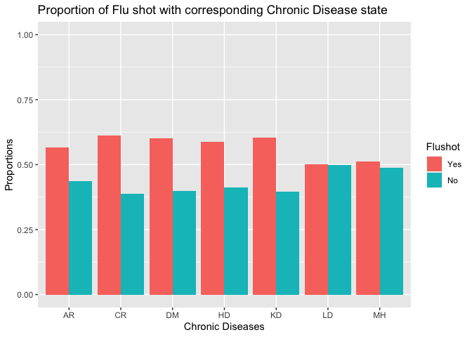

```r
ggplot(data = cd_df1, aes(x = new_col, y = prop, fill = flushot6)) + geom_bar(stat = 'identity', position = 'dodge')  + ylim(0,1) + labs(x = "Chronic Diseases", y = "Proportions", title = "Proportion of Flu shot with corresponding Chronic Disease state", fill = "Flushot")
```

According to the side-by-side bar plots, there may exist a relationship between the type of chronic disease someone has and the proportion of getting a flu shot although further statistical testing would be warranted. The proportions of getting a flu shot was highest among those who were diagnosed with arthritis (AR), cancer (CR), diabetes (DM), heart disease (HD), or kidney disease (KD) compared to those with lung disease (LD) and mental health (MH). It is interesting to point out that lung disease and mental health had very similar proportions between getting the flu shot and not receiving it. Among the groups that had higher proportions of getting the flu shots, it is interesting to point out that most of these groups would be those who would suffer from complications if they were to contract the flu. Perhaps if we were to categorize lung disease separately into COPD and asthma we may see a higher proportion in the number of Yes’s belonging to the COPD group since that disease state could have a higher impact on complications with the flu compared to those having some form of asthma.

```r
#Creating a separate COPD analysis
COPD2 <- brfss2013 %>%
filter(chccopd1 == "Yes") %>%
group_by(flushot6) %>%
filter(!(is.na(flushot6))) %>%
summarise(n=n()) %>%
mutate(prop=n/sum(n))
COPD2
```

```
## # A tibble: 2 × 3
##   flushot6     n  prop
##   <fct>    <int> <dbl>
## 1 Yes      20838 0.556
## 2 No       16646 0.444
```

```r
#Creating a separate asthma analysis
asthma2 <- brfss2013 %>%
filter (asthma3 == "Yes" | asthnow == "Yes") %>%
group_by(flushot6) %>%
filter(!(is.na(flushot6))) %>%
summarise(n=n()) %>%
mutate(prop=n/sum(n))
asthma2
```

```
## # A tibble: 2 × 3
##   flushot6     n  prop
##   <fct>    <int> <dbl>
## 1 Yes      30896 0.498
## 2 No       31149 0.502
```

The proportion of getting a flu shot is higher among those who have a COPD diagnosis compared to those who have a diagnosis of asthma. The asthma proportions are almost identical between getting a flu shot and not getting one.

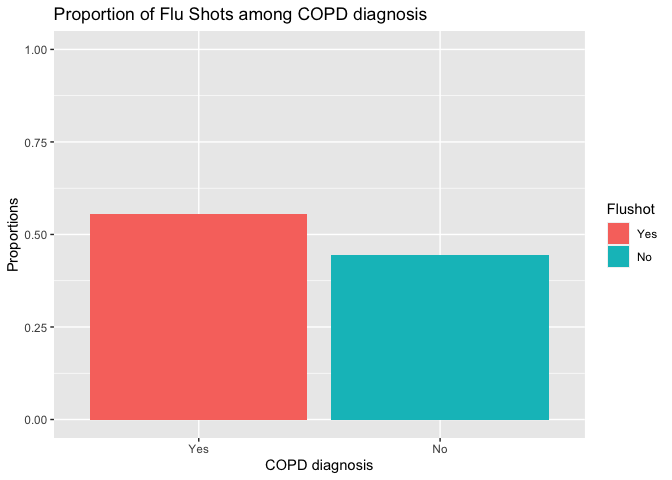

```r
ggplot(data = COPD2, aes(x = flushot6, y = prop, fill = flushot6)) + geom_bar(stat = 'identity', position = 'dodge')  + ylim(0,1) + labs(x = "COPD diagnosis", y = "Proportions", title = "Proportion of Flu Shots among COPD diagnosis", fill = "Flushot")
```

Here, I wanted to demonstrate that there would be a higher proportion of flu shots given among those who have COPD compared to the accumulative amount of lung diseases (asthma and COPD) in the above bar graph. I believe we see this difference since COPD patients are more likely to suffer from complications if they were to contract the flu. However, statistical testing is warranted to prove a difference.

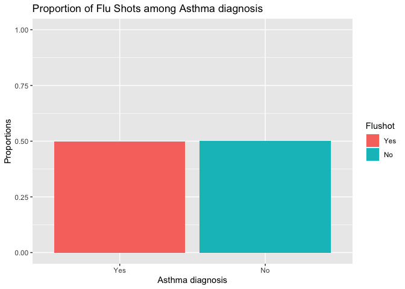

```r
ggplot(data = asthma2, aes(x = flushot6, y = prop, fill = flushot6)) + geom_bar(stat = 'identity', position = 'dodge')  + ylim(0,1) + labs(x = "Asthma diagnosis", y = "Proportions", title = "Proportion of Flu Shots among Asthma diagnosis", fill = "Flushot")
```

According to the bar graph above, the asthma proportions are almost identical between getting a flu shot and not getting one.